# Workflow Basics

2020-09-15 13:15:58

## R is frustrating!!

- Frustration is natural when you start programming in R
- Take comfort in that it’s both typical and temporary: it happens to everyone, and
- The only way to get over it is to keep trying.

Before we go any further, let’s make sure you’ve got a solid foundation in running R code, and that you know about some of the most helpful RStudio features.

## File types

- R-presentations (Rmd special render)
- Text (plain text)

## Coding basics

You can use R as a calculator:

```r
1 / 200 * 30
```

```
## [1] 0.15
```

```r
(59 + 73 + 2) / 3
```

```
## [1] 44.66667
```

```r
sqrt(pi / 2)
```

```
## [1] 1.253314
```

## Assigning to a variable

You can create new objects with `<-`:

```r
x <- 3 * 4
```

## Assigning value to a variable: “assign statement”

All R statements where you create objects, **assignment** statements, have the same form:

```r
object_name <- value
```

In some older scripts you will also see `=` as a variable assigning operator. The difference is that the variable assigned by `<-` will exist in every environment, whereas using `=` will result in a variable that can only be called from the environment that is was created in.

The operator <- can be used anywhere, whereas the operator = is only allowed at the top level (e.g., in the complete expression typed at the command prompt).

So always use `<-` when explicitely assigning a variable in R.

When reading that code say “object name gets value” in your head.

## Writing code

- Write code for humans, not for computers!
- Comment extensively, future you will be grateful
- Do not repeat yourself (will be explained during “Functional programming”)
- Do only one thing at a time!

## Commenting code (example)

```r
# load packages
library(tidyverse)
# setting seed for reproducibility
set.seed(12345)
# function to generate random number in R
?runif
# create 450 random numbers
this_is_an_object <- runif(450)
# create second vector with 450
# random numbers between 0 and 1*10^12
this_is_another_object <- runif(450, 0, 10^12)
# create a dataframe (tibble)
this_is_a_tibble <- as_tibble(cbind(this_is_an_object,
                          this_is_another_object))
```

## Commenting plot code

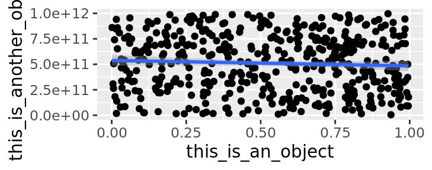

```r
# create a ggplot scatter graph
# with linear regression smoother
ggplot(data = this_is_a_tibble,
  aes(x = this_is_an_object,
      y = this_is_another_object)) + geom_point() +
  geom_smooth(method = "lm")
```

## Inspecting objects (variables)

You can inspect an object by typing its name:

```r
x
```

```
## [1] 12
```

Make another assignment:

```r
this_is_a_really_long_name <- 2.5
this_is_shorter <- 3.0
```

Autocompletion makes it possible to select the proper variable. type “this” to try it out.

## Typos, Case etc.

Make yet another assignment:

```r
r_rocks <- 2 ^ 3
```

Let’s try to inspect it:

```r
r_rock
```

```
#> Error: object 'r_rock' not found
```

```r
R_rocks
```

```
#> Error: object 'R_rocks' not found
```

## R is very picky, and easily insulted

- There’s an implied contract between you and R:
- It will do the tedious computation for you,
- but in return, you must be completely precise in your instructions.
- Typos matter.
- *Case maTTers!!*

## Calling functions

R has a large collection of built-in functions that are called like this:

```r
function_name(arg1 = val1, arg2 = val2, ...)
```

## An example function

- Let’s try using `seq()` which makes regular **seq**uences of numbers
- Type `se` and hit TAB. A popup shows you possible completions. Specify `seq()` by using the arrows.
- Type a “q” to disambiguate, or by using `up`/`down` arrows to select.
- Notice the tooltip that pops up.
- Press F1 to get all the details in help tab in the lower right pane*.

Press TAB. RStudio will add matching opening (`(`) and closing (`)`) parentheses for you. Type the arguments `1, 10` and hit return.

```r
seq(1, 10)
```

```
##  [1]  1  2  3  4  5  6  7  8  9 10
```

## Opening and closing ""

Type this code and notice similar assistance help with the paired quotation marks:

```r
x <- "hello world"
```

“…”, (…), […] and {…} must always come in a pair. RStudio does its best to help you, but it’s still possible to mess up and end up with a mismatch. If this happens, R will show you the continuation character “+”:

```
> x <- "hello
+
```

The `+` tells you that R is waiting for more input; it doesn’t think you’re done yet. Usually that means you’ve forgotten either a `"` or a `)`. Either add the missing pair, or press ESCAPE to abort the expression and try again.

## Environment in RStudio

Now look at your environment in the upper right pane:

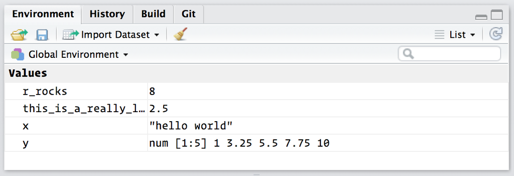

## Exercise 1

1. Why does this code not work?

   ```r
   my_variable <- 10
   my_varıable
   ```

   ```
   ## Error in eval(expr, envir, enclos): object 'my_varıable' not found
   ```

## Exercise 2

1. Tweak each of the following R commands so that they run correctly:

```r
    library(tidyverse)

    ggplot(dota = mpg) +
      geom_point(mapping = aes(x = displ, y = hwy))

    fliter(mpg, cyl = 8)
    filter(diamond, carat > 3)
```